# Análisis de Línea 3 de producción de Pastas

Dra. Eva Marcela Licea De Anda

2024-06-21

Análisis de capacidad de producción del contenido en paquetes de pasta de la línea 3 de la empresa FIDEOS & PASTAS.

Se ha realizado un muestreo sistemático de 5 muestras cada hora, durante 24 horas. La información se encuentra en la siguiente base de datos

# Análisis de Contenido de Pastas

```r
linea3 <- read.table("linea3.csv", sep = ",", header = TRUE)
linea3
```

| x1 | x2 | x3 | x4 | x5 |
| --- | --- | --- | --- | --- |
| 188 | 185 | 208 | 185 | 193 |
| 189 | 186 | 200 | 185 | 195 |
| 214 | 188 | 188 | 185 | 212 |
| 205 | 189 | 204 | 188 | 213 |
| 190 | 190 | 175 | 189 | 184 |
| 185 | 190 | 197 | 190 | 186 |
| 193 | 195 | 190 | 195 | 187 |
| 188 | 196 | 192 | 197 | 208 |
| 213 | 197 | 206 | 202 | 212 |
| 185 | 197 | 199 | 195 | 207 |

[output cut: 14 more lines]

Creamos un vector con todos los datos de los subgrupos de la línea 3

```r
attach(linea3)
vlinea3 = c(x1, x2, x3, x4, x5)
vlinea3
```

```
##   [1] 188 189 214 205 190 185 193 188 213 185 188 211 208 189 213 193 201 195
##  [19] 195 190 206 203 207 204 185 186 188 189 190 190 195 196 197 197 198 199
##  [37] 199 205 185 187 210 191 192 187 191 190 194 205 208 200 188 204 175 197
##  [55] 190 192 206 199 202 191 210 199 188 209 200 208 189 213 190 198 185 204
##  [73] 185 185 185 188 189 190 195 197 202 195 195 195 197 202 197 202 204 204
##  [91] 205 208 211 212 212 215 193 195 212 213 184 186 187 208 212 207 211 214
## [109] 205 200 194 195 193 197 196 195 207 197 198 193
```

## Estadísticos de Tendencia Central

Con la función summary obtenemos los principales estadisticos de tendencia central

```r
summary(vlinea3)
```

```
##    Min. 1st Qu.  Median    Mean 3rd Qu.    Max.
##   175.0   190.0   197.0   197.6   205.0   215.0
```

Guardamos en objetos los valores de los estadísticos, para posteriormente generar un data frame con todos los valores. Valor de la Media

```r
media_linea3 = mean(vlinea3)
media_linea3
```

```
## [1] 197.55
```

Mediana

```r
mediana_linea3 = median(vlinea3)
mediana_linea3
```

```
## [1] 197
```

Moda, empleamos el paquete Modeest

```r
library(modeest)
moda_linea3 = mlv(vlinea3)
moda_linea3
```

```
## [1] 195
```

## Estadísticos de Dispersión

Desviación Estándar

```r
desviacion_est_linea3 = sd(vlinea3)
desviacion_est_linea3
```

```
## [1] 8.988181
```

Varianza

```r
varianza_linea3 = var(vlinea3)
varianza_linea3
```

```
## [1] 80.78739
```

Valor máximo

```r
max_linea3 = max(vlinea3)
max_linea3
```

```
## [1] 215
```

Valor mínimo

```r
min_linea3 = min(vlinea3)
min_linea3
```

```
## [1] 175
```

Rango

```r
rango_linea3 = max_linea3 - min_linea3
rango_linea3
```

```
## [1] 40
```

## Histograma -Gráfica de Capacidad-

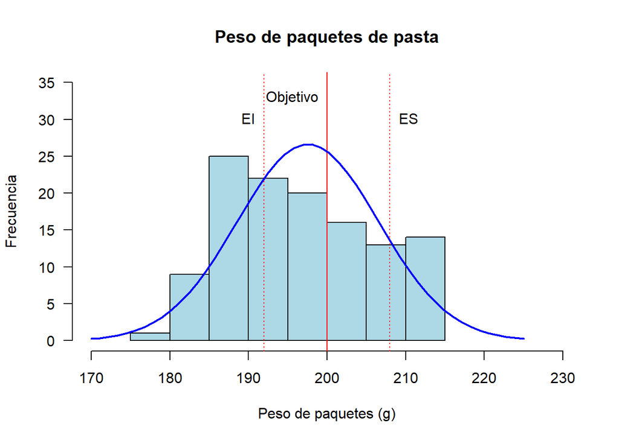

```r
ES <- 208
EI <- 192
N= 200
h = hist(vlinea3, breaks= "sturges", freq = TRUE, right = TRUE,
         col = "lightblue", border = "black",
         main = "Peso de paquetes de pasta",
         ylim= c(0, 35),
         xlim = c (170,230), xlab = "Peso de paquetes (g)",
         ylab = "Frecuencia", las=1)
abline(v = ES, col = "red",lty=3)
text(EI, 30, "EI", cex= NULL, pos=2, col="black")
abline(v = EI, col = "red",lty=3)
text(ES, 30, "ES", cex= NULL, pos=4, col="black")
abline(v = N , col = "red",lty=1)
text(N, 33, "Objetivo", cex= NULL, pos=2, col="black")
myx = seq(170, 225, length.out= 50)
mymean = mean(vlinea3)
mysd = sd(vlinea3)
normal = dnorm(x = myx, mean = mymean, sd = mysd)
multiplier = h$counts / h$density
lines (myx, normal * multiplier[1], col = "blue", lwd = 2)
```

## Prueba de Hipótesis

```r
alpha= 0.05
mu0= 200
n_linea3= length(vlinea3)
n_linea3
```

```
## [1] 120
```

```r
zTest = (media_linea3 - mu0)/ (desviacion_est_linea3/sqrt(n_linea3))
zTest
```

```
## [1] -2.985966
```

```r
zalphaiz <- qnorm(alpha/2,lower.tail = TRUE)
zalphaiz
```

```
## [1] -1.959964
```

```r
zalphader <- qnorm(alpha/2, lower.tail = FALSE)
zalphader
```

```
## [1] 1.959964
```

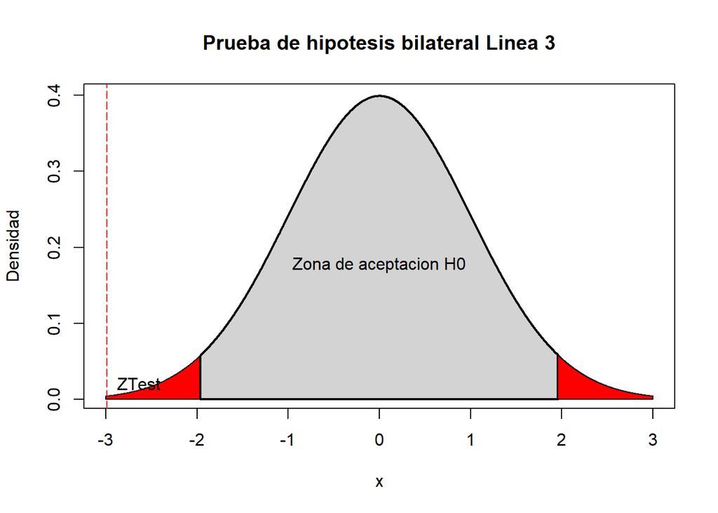

```r
x = pretty(-3:3,n = 50)
y = dnorm(x)
plot(x,y, ylab = "Densidad", type = "l", col = "black",
     main="Prueba de hipotesis bilateral Linea 3")
xi <- c(-3,seq(-3,zalphaiz,by = 0.001),zalphaiz)
yi <- c(0,dnorm(seq(-3,zalphaiz,by = 0.001)),0)
polygon(xi,yi,col = "red",lty = 1,lwd=1)
cor.x = c(zalphaiz, seq(zalphaiz,zalphader, by=0.001),zalphader)
cor.y = c(0,dnorm(seq(zalphaiz, zalphader, by=0.001)),0)
polygon(cor.x,cor.y, col = "lightgrey",lty = 1,lwd=2)
xd = c(zalphader,seq(zalphader,3, by=0.001),3)
yd = c(0,dnorm(seq(zalphader,3,by=0.001)),0)
polygon(xd,yd, angle = 45,col = "red",lty = 1,lwd=1)
text(zTest, 0.02, "ZTest", cex= NULL, pos=4, col="black")
abline(v = zTest, col = "red",lty=5)
text(0, 0.2 , "Zona de aceptacion H0", cex= NULL, pos=1, col="black")
```

### Prueba de normalidad

Determinar si los datos siguien una distribución normal, hacer un gráfico q-q y aplicar el test de Shapiro. Shapiro.test se usa para contrastar si un conjunto de datos sigue una distribución normal o no H0: los datos provienen de una distribución normal, Ha: los datos no provienen de una distribución normal sí p-value ≤ 0.05 se rechaza la hipótesis nula si p-value ≥ 0.05 no se rechaza la hipótesis nula.

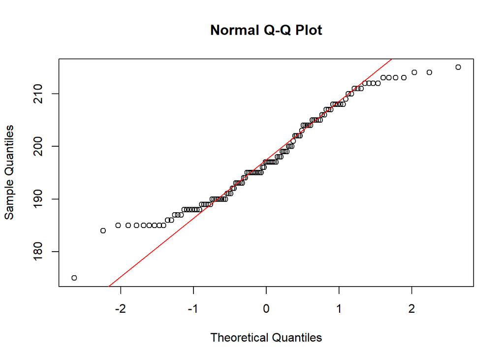

```r
qqnorm(vlinea3)
qqline (vlinea3, col = "red")
```

```r
shapiro.test(vlinea3)
```

```
##
##  Shapiro-Wilk normality test
##
## data:  vlinea3
## W = 0.96035, p-value = 0.001351
```

### Estimación de μx y σx

```r
row.sums <- apply(linea3, 1, mean)
mini <- apply(linea3, 1 , min)
maxi <- apply(linea3, 1 , max)
mu <- mean(row.sums)
mu
```

```
## [1] 197.55
```

```r
rango = maxi - mini
d2 = 2.326
rdesvest = mean(rango)/d2
rdesvest
```

```
## [1] 8.562625
```

## Indices de Capacidad

```r
Cp = (ES-EI)/(6*rdesvest)
Cp
```

```
## [1] 0.311431
```

```r
Cr = (6*rdesvest)/(ES-EI)
Cr
```

```
## [1] 3.210985
```

```r
Cpi = (mu-EI)/(3*rdesvest)
Cpi
```

```
## [1] 0.2160552
```

```r
Cps = (ES-mu)/(3*rdesvest)
Cps
```

```
## [1] 0.4068067
```

```r
Cpk = min(Cpi,Cps)
Cpk
```

```
## [1] 0.2160552
```

### Indice Taguchi

```r
tau = sqrt((rdesvest^2)+((mu-N)^2))
Cpm = (ES-EI)/(6*tau)
Cpm
```

```
## [1] 0.2994156
```

### Índice Z

Partes por millón fuera de especificación con menor cantidad de pasta

```r
zi = 3*Cpi
Pzi = 1-pnorm(zi)
PPMFEi = Pzi*1000000
PPMFEi
```

```
## [1] 258438.9
```

Partes por millón fuera de especificación con mayor cantidad de pasta

```r
zs = 3*Cps
Pzs = 1-pnorm(zs)
PPMFEs = Pzs*1000000
PPMFEs
```

```
## [1] 111152.8
```

Partes por millón fuera de especificación

```r
zbench = qnorm(1-(Pzi+Pzs))
Pzbench = 1-pnorm(zbench)
PPMFE = Pzbench*1000000
PPMFE
```

```
## [1] 369591.7
```

### Resumen de todos los índices de capacidad

```r
Resumen_indices_linea3 = data.frame(Cp,Cpi,Cps,Cpk,zi,Pzi,PPMFEi,zs,Pzs,PPMFEs,zbench,Pzbench,PPMFE,Cpm)
Resumen_indices_linea3
```

| Cp | Cpi | Cps | Cpk | zi | Pzi | PPMFEi | zs | Pzs | PPMFEs | zbench | Pzbench | PPMFE | Cpm |
| --- | --- | --- | --- | --- | --- | --- | --- | --- | --- | --- | --- | --- | --- |
| 0.311431 | 0.2160552 | 0.4068067 | 0.2160552 | 0.6481657 | 0.2584389 | 258438.9 | 1.22042 | 0.1111528 | 111152.8 | 0.3329349 | 0.3695917 | 369591.7 | 0.2994156 |

# Analisis de capacidad con la librería SixSigma

```r
library(SixSigma)
```

[figure not shown]

```r
ss.study.ca(vlinea3, LSL= 192, USL= 208,
            Target = 200, alpha=0.5,
            f.main= "Analisis de Capacidad línea 2",
            f.colours= c("#1b859d", "#356e84", "#50576b", "#6a3f52", "#842839"),"midnightblue")
```

# Bibliografía

Fuente original: http://www.ptolomeo.unam.mx:8080/xmlui/bitstream/handle/132.248.52.100/16773/Tesis.pdf?sequence=3&isAllowed=y Adaptado para el estudio de Control Estadístico de Procesos. Mejía Cervantes Karen Evelyn. Análisis de Control Estadístico de calidad utilizando R R Markdown: The Definitive guide. Yihui Xie, J. J. Allaire, Garrett Grolemund https://bookdown.org/yihui/rmarkdown/